# Day 10 - Exercise 2

```python
import pandas as pd

#-------------------- Import <Titles> Data-Set --------------------#

titles = pd.read_csv('titles.csv')

print('\n#---------- Titles Data-Set Glimpse ----------#')

titles.head()
```

```
#---------- Titles Data-Set Glimpse ----------#
```

|  | title | year |
| --- | --- | --- |
| 0 | Tasveer Mere Sanam | 1996 |
| 1 | Only You | 1994 |
| 2 | El pueblo del terror | 1970 |
| 3 | Machine | 2007 |
| 4 | MARy | 2008 |

```python
#-------------------- Import <Cast> Data-Set --------------------#

cast = pd.read_csv('cast.csv')

print('\n#---------- Cast Data-Set Glimpse ----------#')

cast.head(10)
```

```
#---------- Cast Data-Set Glimpse ----------#
```

|  | title | year | name | type | character | n |
| --- | --- | --- | --- | --- | --- | --- |
| 0 | Closet Monster | 2015 | Buffy #1 | actor | Buffy 4 | 31.0 |
| 1 | Suuri illusioni | 1985 | Homo $ | actor | Guests | 22.0 |
| 2 | Battle of the Sexes | 2017 | $hutter | actor | Bobby Riggs Fan | 10.0 |
| 3 | Secret in Their Eyes | 2015 | $hutter | actor | 2002 Dodger Fan | NaN |
| 4 | Steve Jobs | 2015 | $hutter | actor | 1988 Opera House Patron | NaN |
| 5 | Straight Outta Compton | 2015 | $hutter | actor | Club Patron | NaN |
| 6 | Straight Outta Compton | 2015 | $hutter | actor | Dopeman | NaN |
| 7 | For Thy Love 2 | 2009 | Bee Moe $lim | actor | Thug 1 | NaN |
| 8 | Lapis, Ballpen at Diploma, a True to Life Journey | 2014 | Jori ' Danilo' Jurado Jr. | actor | Jaime (young) | 9.0 |
| 9 | Desire (III) | 2014 | Syaiful 'Ariffin | actor | Actor Playing Eteocles from 'Antigone' | NaN |

# What are the ten most common movie names of all time?

```python
top_ten_movies = titles['title'].value_counts().head(10).reset_index()
```

```python
top_ten_movies.columns = ['title', 'No_Of_Count']

print("Top 10 Common Movies Are:\n")

print(top_ten_movies)
```

```
Top 10 Common Movies Are:

                  title  No_Of_Count
0                Hamlet           20
1                Carmen           17
2               Macbeth           16
3            Temptation           12
4          The Outsider           12
5                  Maya           12
6               Freedom           11
7             Honeymoon           11
8               Othello           11
9  The Three Musketeers           11
```

# Which three years of the 1930s saw the most films released?

```python
movies_1930s = cast[cast['year'].between(1930, 1939)]

top_three_years_1930s = movies_1930s['year'].value_counts().head(3).reset_index()
```

```python
top_three_years_1930s.columns = ['year', 'No_Of_Films']

print("\nThe most films released in 3 years of 1930s are:\n")

print(top_three_years_1930s)
```

```
The most films released in 3 years of 1930s are:

   year  No_Of_Films
0  1937        27676
1  1936        26019
2  1938        25450
```

# Plot the number of films that have been released each decade over the history of cinema.

```python
!pip install matplotlib
```

```python
import matplotlib.pyplot as plt

titles['decade'] = (titles['year'] // 10) * 10
```

```python
films_per_decade = titles['decade'].value_counts().sort_index()
```

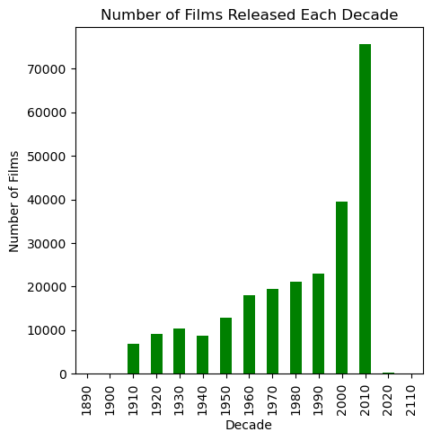

```python
plt.figure(figsize=(5, 5))

films_per_decade.plot(kind='bar', color='green')

plt.title('Number of Films Released Each Decade')

plt.xlabel('Decade')

plt.ylabel('Number of Films')

plt.show()
```

# Plot the number of "Hamlet- films made each decade.

```python
hamlet_films = titles[titles['title'] == 'Hamlet']
```

```python
hamlet_films['decade'] = (hamlet_films['year'] // 10) * 10
```

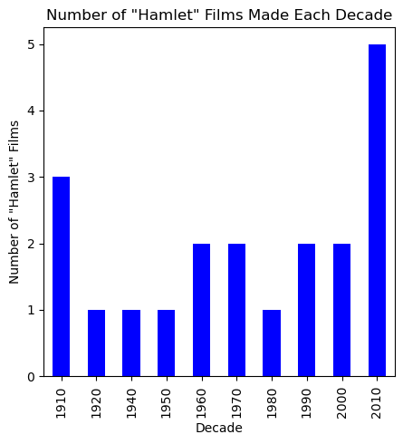

```python
hamlet_films_per_decade = hamlet_films['decade'].value_counts().sort_index()

plt.figure(figsize=(5, 5))

hamlet_films_per_decade.plot(kind='bar', color='blue')

plt.title('Number of "Hamlet" Films Made Each Decade')

plt.xlabel('Decade')

plt.ylabel('Number of "Hamlet" Films')

plt.show()
```

# Plot the number of "Rustler" characters in each decade of the history of film.

```python
cast['decade'] = (cast['year'] // 10) * 10
```

```python
rustler_characters = cast[cast['character'] == 'Rustler']
```

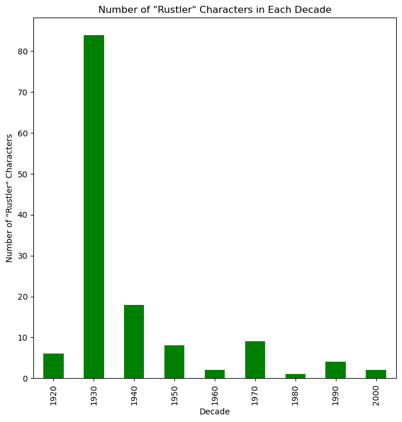

```python
rustlers_per_decade = rustler_characters['decade'].value_counts().sort_index()

plt.figure(figsize=(8,8))

rustlers_per_decade.plot(kind='bar', color='green')

plt.title('Number of "Rustler" Characters in Each Decade')

plt.xlabel('Decade')

plt.ylabel('Number of "Rustler" Characters')

plt.show()
```

# Plot the number of "Hamlet" characters each decade.

```python
cast['decade'] = (cast['year'] // 10) * 10

hamlet_characters = cast[cast['character'] == 'Hamlet']
```

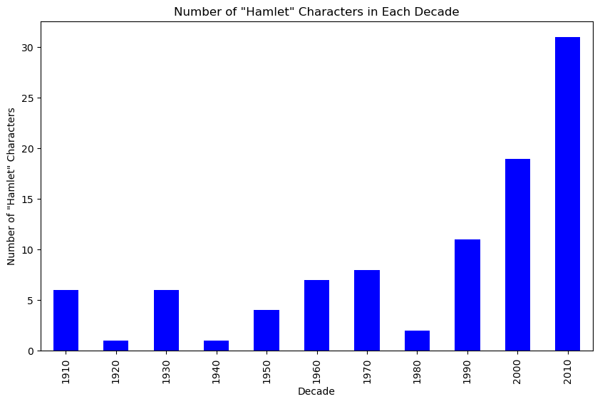

```python
hamlet_per_decade = hamlet_characters['decade'].value_counts().sort_index()

plt.figure(figsize=(10, 6))

hamlet_per_decade.plot(kind='bar', color='blue')

plt.title('Number of "Hamlet" Characters in Each Decade')

plt.xlabel('Decade')

plt.ylabel('Number of "Hamlet" Characters')

plt.show()
```

# What are the 11 most common character names in movie history?

```python
comm_character_names = cast['character'].value_counts().head(11).reset_index()

comm_character_names.columns = ['character', 'Total_Count']
```

```python
print("11 most common character names in movie history are: \n")

print(comm_character_names)
```

```
11 most common character names in movie history are:

      character  Total_Count
0       Himself        20746
1        Dancer        12477
2         Extra        11948
3      Reporter         8434
4       Student         7773
5        Doctor         7669
6   Party Guest         7245
7     Policeman         7029
8         Nurse         6999
9     Bartender         6802
10      Herself         6705
```

# Who are the 10 people most often credited as "Herself" in film history?

```python
people_herself = cast[cast['character'] == 'Herself']

top_10_herself = people_herself['name'].value_counts().head(10).reset_index()

top_10_herself.columns = ['name', 'Total_count']
```

```python
print("10 people most credited as 'Herself' in film history are: \n")

print(top_10_herself)
```

```
10 people most credited as 'Herself' in film history are:

                        name  Total_count
0         Queen Elizabeth II           12
1             Joyce Brothers            9
2                Luisa Horga            9
3     Mar?a Luisa (V) Mart?n            9
4          Margaret Thatcher            8
5            Hillary Clinton            8
6           In?s J. Southern            6
7  Mar?a Isabel (III) Mart?n            6
8             Marta Berrocal            6
9                Sumie Sakai            6
```

# Who are the 10 people most often credited as "Himself" in film history?

```python
people_himself = cast[cast['character'] == 'Himself']

top_10_himself = people_himself['name'].value_counts().head(10).reset_index()

top_10_himself.columns = ['name', 'Total_count']
```

```python
print("\n 10 people most credited as 'Himself' in film history are: \n")

print(top_10_himself)
```

```
 10 people most credited as 'Himself' in film history are:

                    name  Total_count
0           Adolf Hitler           99
1          Richard Nixon           44
2          Ronald Reagan           41
3        John F. Kennedy           37
4         George W. Bush           25
5      Winston Churchill           24
6     Martin Luther King           23
7             Ron Jeremy           22
8           Bill Clinton           22
9  Franklin D. Roosevelt           21
```

# Which actors or actresses appeared in the most movies in the year 1945?

```python
movies_1945 = cast[cast['year'] == 1945]

actor_appearances_1945 = movies_1945['name'].value_counts()

top_actor_1945 = actor_appearances_1945.idxmax()

most_appearances_1945 = actor_appearances_1945.max()
```

```python
print(f"\n The actor/actress who appeared in the most movies in 1945 is:- \n")

print(top_actor_1945, "with",most_appearances_1945, "appearances.")
```

```
 The actor/actress who appeared in the most movies in 1945 is:-

Emmett Vogan with 39 appearances.
```

# Which actors or actresses appeared in the most movies in the year 1985?

```python
movies_1945 = cast[cast['year'] == 1985]

actor_appearances_1945 = movies_1945['name'].value_counts()

top_actor_1945 = actor_appearances_1945.idxmax()

most_appearances_1945 = actor_appearances_1945.max()
```

```python
print(f"\n The actor/actress who appeared in the most movies in 1985 is:- \n")

print(top_actor_1945, "with",most_appearances_1945, "appearances.")
```

```
 The actor/actress who appeared in the most movies in 1985 is:-

Mammootty with 22 appearances.
```

# Plot how many roles Mammootty has played in each year of his career.

```python
mammootty_roles = cast[cast['name'] == 'Mammootty']

roles_per_year = mammootty_roles['year'].value_counts().sort_index()
```

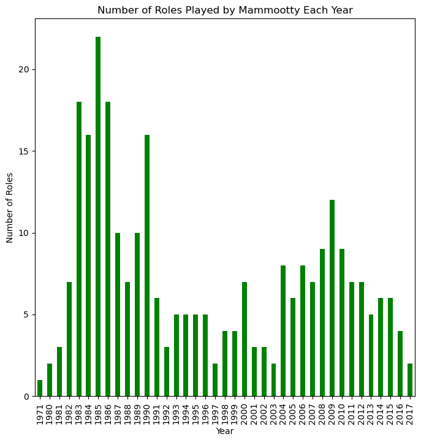

```python
plt.figure(figsize=(8, 8))

roles_per_year.plot(kind='bar', color='green')

plt.title('Number of Roles Played by Mammootty Each Year')

plt.xlabel('Year')

plt.ylabel('Number of Roles')

plt.show()
```

# What are the 10 most frequent roles that start with the phrase "Patron in"?

```python
patron_roles = cast[cast['character'].str.startswith('Patron in')]

top_10_patrons = patron_roles['character'].value_counts().head(10).reset_index()

top_10_patrons.columns = ['Role', 'Total_Count']
```

```python
print("\n Top 10 starting phrase Patrons roles are: \n")

print(top_10_patrons)
```

```
 Top 10 starting phrase Patrons roles are:

                           Role  Total_Count
0       Patron in Frisky Rabbit           16
1  Patron in Chinese Restaurant            9
2    Patron in the Coffee House            9
3     Patron in Billiard Parlor            5
4          Patron in restaurant            4
5                 Patron in Bar            4
6             Patron in cabaret            3
7          Patron in Restaurant            3
8                Patron in Club            3
9               Patron in booth            2
```

# What are the 10 most frequent roles that start with the word "Science"?

```python
science_roles = cast[cast['character'].str.startswith('Science')]

top_10_science = science_roles['character'].value_counts().head(10).reset_index()

top_10_science.columns = ['Role', 'Total_Count']
```

```python
print("\n Top 10 frequent roles starting with 'Science' are: \n")

print(top_10_science)
```

```
 Top 10 frequent roles starting with 'Science' are:

                   Role  Total_Count
0       Science Teacher           60
1       Science Student            9
2  Science Fair Student            9
3    Science Fair Judge            6
4      Science Fair Kid            5
5      Science Reporter            5
6           Science Kid            5
7   Science Club Member            5
8   Science Promo Cadet            5
9               Science            4
```

# Plot the n-values of the roles that Judi Dench has played over her career.

```python
judi_roles = cast[cast['name'] == 'Judi Dench']

#-------------------- NaN Values --------------------#

judi_roles = judi_roles.dropna(subset=['n'])

#----------------------------------------#

judi_roles = judi_roles.sort_values(by='year')
```

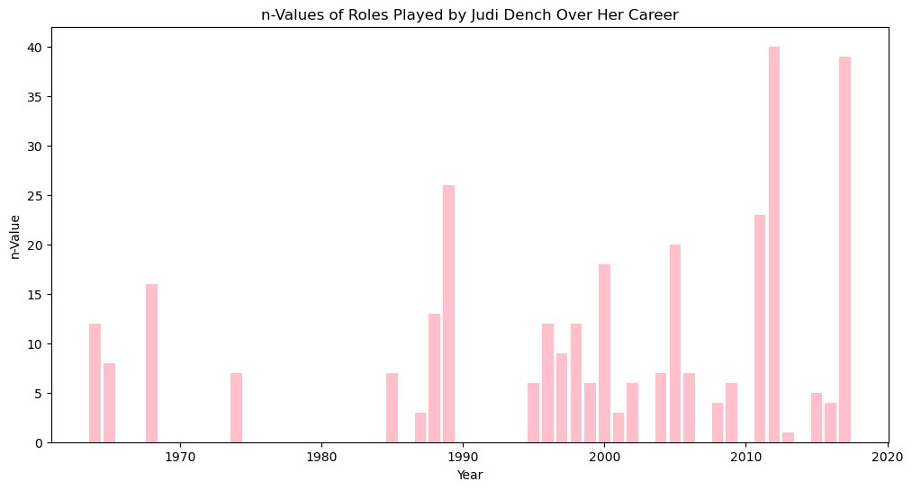

```python
plt.figure(figsize=(12, 6))

plt.bar(judi_roles['year'], judi_roles['n'], color='pink')

plt.title('n-Values of Roles Played by Judi Dench Over Her Career')

plt.xlabel('Year')

plt.ylabel('n-Value')

plt.show()
```

# Plot the n-values of Cary Grant's roles through his career.

```python
grant_roles = cast[cast['name'] == 'Cary Grant']

#-------------------- NaN Values --------------------#

grant_roles = grant_roles.dropna(subset=['n'])

#----------------------------------------#

grant_roles = grant_roles.sort_values(by='year')
```

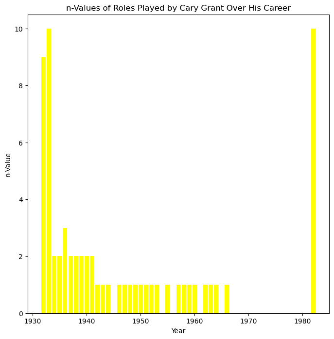

```python
plt.figure(figsize=(8, 8))

plt.bar(grant_roles['year'], grant_roles['n'], color='yellow')

plt.title('n-Values of Roles Played by Cary Grant Over His Career')

plt.xlabel('Year')

plt.ylabel('n-Value')

plt.show()
```

# Plot the n-value of the roles that Sidney Poitier has acted over the years.

```python
sidney_roles = cast[cast['name'] == 'Sidney Poitier']

#-------------------- NaN Values --------------------#

sidney_roles = sidney_roles.dropna(subset=['n'])

#----------------------------------------#

sidney_roles = sidney_roles.sort_values(by='year')
```

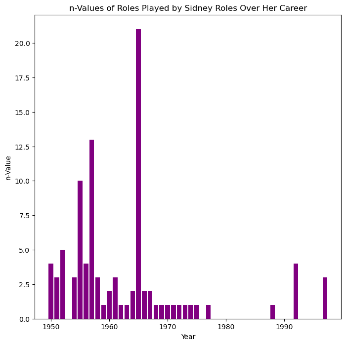

```python
plt.figure(figsize=(8, 8))

plt.bar(sidney_roles['year'], sidney_roles['n'], color='purple')

plt.title('n-Values of Roles Played by Sidney Roles Over Her Career')

plt.xlabel('Year')

plt.ylabel('n-Value')

plt.show()
```

# How many leading (n=1) roles were available to actors, and how many to actresses, in the 1950s?

```python
leading_roles_1950s = cast[(cast['n'] == 1) & (cast['year'].between(1950, 1959))]

#-------------------- Actors and Actresses leading roles --------------------#

leading_roles_actors = leading_roles_1950s[leading_roles_1950s['type'] == 'actor']

leading_roles_actresses = leading_roles_1950s[leading_roles_1950s['type'] == 'actress']

#-------------------- Total_Counts (Actors and Actresses) --------------------#

count_leading_roles_actors = len(leading_roles_actors)

count_leading_roles_actresses = len(leading_roles_actresses)
```

```python
print(f"\n No. of leading roles (n=1) available to actors in the 1950s are: {count_leading_roles_actors}")

print(f"\n No. of leading roles (n=1) available to actresses in the 1950s are: {count_leading_roles_actresses}")
```

```
 No. of leading roles (n=1) available to actors in the 1950s are: 6692

 No. of leading roles (n=1) available to actresses in the 1950s are: 3040
```

# How many supporting (n=2) roles were available to actors, and how many to actresses. in the 1950s?

```python
supporting_roles_1950s = cast[(cast['n'] == 2) & (cast['year'].between(1950, 1959))]

#-------------------- Actors and Actresses leading roles --------------------#

supporting_roles_actors = supporting_roles_1950s[supporting_roles_1950s['type'] == 'actor']

supporting_roles_actresses = supporting_roles_1950s[supporting_roles_1950s['type'] == 'actress']

#-------------------- Total_Counts (Actors and Actresses) --------------------#

total_supporting_roles_actors = len(supporting_roles_actors)

total_supporting_roles_actresses = len(supporting_roles_actresses)
```

```python
print(f"\n No. of supporting roles (n=2) available to actors in the 1950s are: {total_supporting_roles_actors}")

print(f"\n No. of supporting roles (n=2) available to actresses in the 1950s are: {total_supporting_roles_actresses}")
```

```
 No. of supporting roles (n=2) available to actors in the 1950s are: 4640

 No. of supporting roles (n=2) available to actresses in the 1950s are: 4635
```